# Forest dynamics

Miquel De Caceres

2021-12-16

## About this vignette

This document describes how to run the forest dynamics model of `medfate`. This document is meant to teach users to run the simulation model within R. Details of the model design and formulation can be found at https://emf-creaf.github.io/medfatebook/index.html.

## Preparing model inputs

Any forest dynamics model needs information on climate, vegetation and soils of the forest stand to be simulated. Moreover, since models in `medfate` differentiate between species, information on species-specific model parameters is also needed. In this subsection we explain the different steps to prepare the data needed to run function `fordyn()`.

## Preparing model inputs

Model inputs are explained in greater detail in vignette ‘*Simulation inputs*’. Here we only review the different steps required to run function `fordyn()`.

### Soil, vegetation, meteorology and species data

Soil information needs to be entered as a `data frame` with soil layers in rows and physical attributes in columns. Soil physical attributes can be initialized to default values, for a given number of layers, using function `defaultSoilParams()`:

```r
spar = defaultSoilParams(2)
```

The soil input for water balance simulation is actually a list of class `soil` that is created using a function with the same name:

```r
examplesoil = soil(spar)
```

As explained in the package overview, models included in `medfate` were primarily designed to be ran on **forest inventory plots**. Here we use the example object provided with the package:

```r
data(exampleforestMED)
exampleforestMED
```

```
## $ID
## [1] "1"
##
## $patchsize
## [1] 10000
##
## $treeData
##   Species   N   DBH Height Z50  Z95
## 1     148 168 37.55    800 750 3000
## 2     168 384 14.60    660 750 3000
##
## $shrubData
##   Species Cover Height Z50  Z95
## 1     165  3.75     80 300 1500
##
## $herbCover
## [1] 10
##
## $herbHeight
## [1] 20
##
## attr(,"class")
## [1] "forest" "list"
```

In the basic water balance, only mean temperature, precipitation and potential evapotranspiration is required, but radiation may also be necessary to simulate snow melt.

```r
data(examplemeteo)
head(examplemeteo)
```

```
##            MeanTemperature MinTemperature MaxTemperature Precipitation
## 2001-01-01      3.57668969     -0.5934215       6.287950      4.869109
## 2001-01-02      1.83695972     -2.3662458       4.569737      2.498292
## 2001-01-03      0.09462563     -3.8541036       2.661951      0.000000
## 2001-01-04      1.13866156     -1.8744860       3.097705      5.796973
## 2001-01-05      4.70578690      0.3288287       7.551532      1.884401
## 2001-01-06      4.57036721      0.5461322       7.186784     13.359801
##            MeanRelativeHumidity MinRelativeHumidity MaxRelativeHumidity
## 2001-01-01             78.73709            65.15411           100.00000
## 2001-01-02             69.70800            57.43761            94.71780
## 2001-01-03             70.69610            58.77432            94.66823
## 2001-01-04             76.89156            66.84256            95.80950
## 2001-01-05             76.67424            62.97656           100.00000
## 2001-01-06             89.01940            74.25754           100.00000
##            Radiation WindSpeed WindDirection       PET
## 2001-01-01  12.89251  2.000000           172 1.3212770
## 2001-01-02  13.03079  7.662544           278 2.2185985
## 2001-01-03  16.90722  2.000000           141 1.8045176
## 2001-01-04  11.07275  2.000000           172 0.9200627
## 2001-01-05  13.45205  7.581347           321 2.2914449
## 2001-01-06  12.84841  6.570501           141 1.7255058
```

Finally, simulations in `medfate` require a data frame with species parameter values, which we load using defaults for Catalonia (NE Spain):

```r
data("SpParamsMED")
```

### Simulation control

Apart from data inputs, the behaviour of simulation models can be controlled using a set of global parameters. The default parameterization is obtained using function `defaultControl()`:

```r
control = defaultControl("Granier")
```

Here we will run simulations of forest dynamics using the basic water balance model (i.e. `transpirationMode = "Granier"`). The complexity of the soil water balance calculations can be changed by using `"Sperry"` as input to `defaultControl()`. However, when running `fordyn()` sub-daily output will never be stored (i.e. setting `subdailyResults = TRUE` is useless).

## Executing the forest dynamics model

In this vignette we will fake a three-year weather input by repeating the example weather data frame three times, while reducing precipitation of the second year to the half.

```r
meteo2001 = examplemeteo
meteo2002 = examplemeteo
meteo2002$Precipitation = meteo2002$Precipitation/2
meteo2003 = examplemeteo
row.names(meteo2002) = seq(as.Date("2002-01-01"),
                           as.Date("2002-12-31"), by="day")
row.names(meteo2003) = seq(as.Date("2003-01-01"),
                           as.Date("2003-12-31"), by="day")
meteo_01_03 = rbind(meteo2001, meteo2002, meteo2003)
```

Now we run the forest dynamics model using all inputs (note that no intermediate input object is needed, as in `spwb()` or `growth()`):

```r
fd<-fordyn(exampleforestMED, examplesoil, SpParamsMED, meteo_01_03, control,
           latitude = 41.82592, elevation = 100)
```

```
## Simulating forest dynamics for year 2001 (1/3)
##    (a) Growth/mortality
##    (b) Recruitment
##        Coldest month mean temp. (Celsius): 0.05   Moisture index: 0.36   FPAR (%): 35.7
##        Tree species with seed rain: 148,168 recruited: <none>
##    (c) Summaries
## Simulating forest dynamics for year 2002 (2/3)
##    (a) Growth/mortality
##    (b) Recruitment
##        Coldest month mean temp. (Celsius): 0.05   Moisture index: 0.18   FPAR (%): 36
##        Tree species with seed rain: 148,168 recruited: <none>
##    (c) Summaries
## Simulating forest dynamics for year 2003 (3/3)
##    (a) Growth/mortality
##    (b) Recruitment
##        Coldest month mean temp. (Celsius): 0.05   Moisture index: 0.36   FPAR (%): 35.9
##        Tree species with seed rain: 148,168 recruited: <none>
##    (c) Summaries
```

It is worth noting that, while `fordyn()` calls function `growth()` internally for each simulated year, the `verbose` option of the control parameters only affects function `fordyn()` (i.e. all console output from `growth()` is hidden). Recruitment and summaries are done only once a year at the level of function `fordyn()`.

## Inspecting model outputs

### Stand, species and cohort summaries and plots

Among other outputs, function `fordyn()` calculates standard summary statistics that describe the structural and compositional state of the forest at each time step. For example, we can access stand-level statistics using:

```r
fd$StandSummary
```

```
##   Step LeafAreaIndex TreeDensityLive TreeBasalAreaLive ShrubCoverLive MaxHeight
## 1    0      1.972712        552.0000          25.03330           3.75  800.0000
## 2    1      1.920101        546.3412          24.94302           3.75  802.1067
## 3    2      1.824461        540.7403          24.69822           3.75  802.2443
## 4    3      1.784226        535.1969          24.75506           3.75  806.1676
```

```r
fd$SpeciesSummary
```

```
##    Step Species LeafAreaIndex TreeDensityLive TreeBasalAreaLive ShrubCoverLive
## 1     0     148    1.00643723        168.0000         18.604545           0.00
## 2     0     165    0.03965932          0.0000          0.000000           3.75
## 3     0     168    0.92661573        384.0000          6.428754           0.00
## 4     1     148    0.97901457        166.2777         18.515438           0.00
## 5     1     165    0.03965932          0.0000          0.000000           3.75
## 6     1     168    0.90142670        380.0634          6.427579           0.00
## 7     2     148    0.92912044        164.5731         18.332285           0.00
## 8     2     165    0.03965932          0.0000          0.000000           3.75
## 9     2     168    0.85568134        376.1672          6.365931           0.00
## 10    3     148    0.90759897        162.8860         18.333646           0.00
## 11    3     165    0.03965932          0.0000          0.000000           3.75
## 12    3     168    0.83696796        372.3109          6.421411           0.00
##    MaxHeight
## 1   800.0000
## 2    80.0000
## 3   660.0000
## 4   802.1067
## 5    80.0000
## 6   662.5325
## 7   802.2443
## 8    80.0000
## 9   662.6937
## 10  806.1676
## 11   80.0000
## 12  667.2288
```

Package `medfate` provides a simple `plot` function for objects of class `fordyn`. For example, we can show the interannual variation in stand-level basal area using:

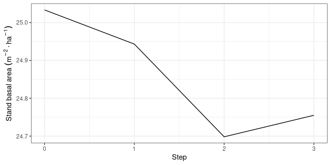

```r
plot(fd, type = "StandBasalArea")
```

### Tree/shrub tables

Another useful output of `fordyn()` are tables in long format with cohort structural information (i.e. DBH, height, density, etc) for each time step:

```r
fd$TreeTable
```

```
##   Step Year Cohort Species             Name        N      DBH   Height Z50  Z95
## 1    0   NA T1_148     148 Pinus halepensis 168.0000 37.55000 800.0000 750 3000
## 2    0   NA T2_168     168     Quercus ilex 384.0000 14.60000 660.0000 750 3000
## 3    1 2001 T1_148     148 Pinus halepensis 166.2777 37.65347 802.1067 750 3000
## 4    1 2001 T2_168     168     Quercus ilex 380.0634 14.67408 662.5325 750 3000
## 5    2 2002 T1_148     148 Pinus halepensis 164.5731 37.66031 802.2443 750 3000
## 6    2 2002 T2_168     168     Quercus ilex 376.1672 14.67897 662.6937 750 3000
## 7    3 2003 T1_148     148 Pinus halepensis 162.8860 37.85625 806.1676 750 3000
## 8    3 2003 T2_168     168     Quercus ilex 372.3109 14.81895 667.2288 750 3000
```

```r
fd$DeadTreeTable
```

```
##   Step Year Cohort Species             Name        N      DBH   Height Z50  Z95
## 1    1 2001 T1_148     148 Pinus halepensis 1.722253 37.65347 802.1067 750 3000
## 2    1 2001 T2_168     168     Quercus ilex 3.936579 14.67408 662.5325 750 3000
## 3    2 2002 T1_148     148 Pinus halepensis 1.704598 37.66031 802.2443 750 3000
## 4    2 2002 T2_168     168     Quercus ilex 3.896223 14.67897 662.6937 750 3000
## 5    3 2003 T1_148     148 Pinus halepensis 1.687123 37.85625 806.1676 750 3000
## 6    3 2003 T2_168     168     Quercus ilex 3.856281 14.81895 667.2288 750 3000
```

### Accessing the output from function growth()

Since function `fordyn()` makes internal calls to function `growth()`, it stores the result in a vector called `GrowthResults`, which we can use to inspect intra-annual patterns of desired variables. For example, the following shows the leaf area for individuals of the three cohorts during the three consecutive years:

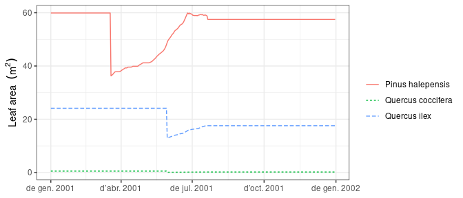

```r
plot(fd$GrowthResults[[1]], "LeafArea", bySpecies = T)
```

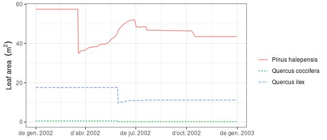

```r
plot(fd$GrowthResults[[2]], "LeafArea", bySpecies = T)
```

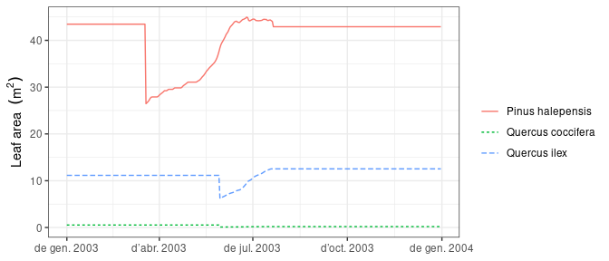

```r
plot(fd$GrowthResults[[3]], "LeafArea", bySpecies = T)
```

where we see that the second (drier) year, resulted in a decrease in leaf area, due to the sink limitation caused by drought, and the third (normal) year lead to a recovery of leaf area. Note also the sink limitation to sapwood area (hence diameter) growth during the second year:

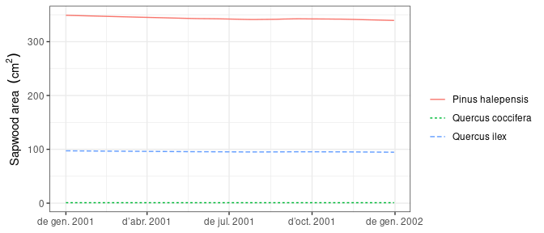

```r
plot(fd$GrowthResults[[1]], "SapwoodArea", bySpecies = T)
```

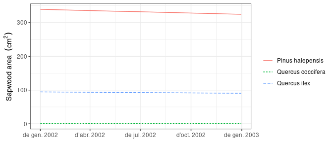

```r
plot(fd$GrowthResults[[2]], "SapwoodArea", bySpecies = T)
```

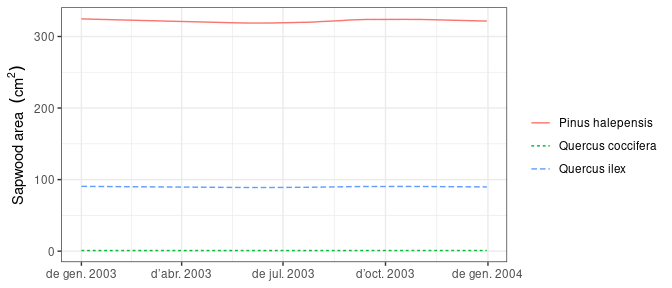

```r
plot(fd$GrowthResults[[3]], "SapwoodArea", bySpecies = T)
```

Finally, we can create interactive plots for particular steps using function `shinyplot`, e.g.:

```r
shinyplot(fd$GrowthResults[[1]])
```